# Risk Factor Analysis

## Outcome Variable

**Outcome Variable:** ever_wasted

## Predictor Variables

**Intervention Variable:** birthlen

**Adjustment Set:**

unadjusted

## Stratifying Variables

The analysis was stratified on these variable(s):

- agecat
- studyid
- country

## Data Summary

| agecat | studyid | country | birthlen | ever_wasted | n_cell | n |
| --- | --- | --- | --- | --- | --- | --- |
| 0-24 months (no birth wast) | ki0047075b-MAL-ED | BANGLADESH | >=50 cm | 0 | 23 | 254 |
| 0-24 months (no birth wast) | ki0047075b-MAL-ED | BANGLADESH | >=50 cm | 1 | 6 | 254 |
| 0-24 months (no birth wast) | ki0047075b-MAL-ED | BANGLADESH | <48 cm | 0 | 105 | 254 |
| 0-24 months (no birth wast) | ki0047075b-MAL-ED | BANGLADESH | <48 cm | 1 | 35 | 254 |
| 0-24 months (no birth wast) | ki0047075b-MAL-ED | BANGLADESH | [48-50) cm | 0 | 70 | 254 |
| 0-24 months (no birth wast) | ki0047075b-MAL-ED | BANGLADESH | [48-50) cm | 1 | 15 | 254 |
| 0-24 months (no birth wast) | ki0047075b-MAL-ED | BRAZIL | >=50 cm | 0 | 32 | 188 |
| 0-24 months (no birth wast) | ki0047075b-MAL-ED | BRAZIL | >=50 cm | 1 | 2 | 188 |
| 0-24 months (no birth wast) | ki0047075b-MAL-ED | BRAZIL | <48 cm | 0 | 72 | 188 |
| 0-24 months (no birth wast) | ki0047075b-MAL-ED | BRAZIL | <48 cm | 1 | 6 | 188 |
| 0-24 months (no birth wast) | ki0047075b-MAL-ED | BRAZIL | [48-50) cm | 0 | 72 | 188 |
| 0-24 months (no birth wast) | ki0047075b-MAL-ED | BRAZIL | [48-50) cm | 1 | 4 | 188 |
| 0-24 months (no birth wast) | ki0047075b-MAL-ED | INDIA | >=50 cm | 0 | 17 | 199 |
| 0-24 months (no birth wast) | ki0047075b-MAL-ED | INDIA | >=50 cm | 1 | 8 | 199 |
| 0-24 months (no birth wast) | ki0047075b-MAL-ED | INDIA | <48 cm | 0 | 66 | 199 |
| 0-24 months (no birth wast) | ki0047075b-MAL-ED | INDIA | <48 cm | 1 | 38 | 199 |
| 0-24 months (no birth wast) | ki0047075b-MAL-ED | INDIA | [48-50) cm | 0 | 46 | 199 |
| 0-24 months (no birth wast) | ki0047075b-MAL-ED | INDIA | [48-50) cm | 1 | 24 | 199 |
| 0-24 months (no birth wast) | ki0047075b-MAL-ED | NEPAL | >=50 cm | 0 | 33 | 172 |
| 0-24 months (no birth wast) | ki0047075b-MAL-ED | NEPAL | >=50 cm | 1 | 5 | 172 |
| 0-24 months (no birth wast) | ki0047075b-MAL-ED | NEPAL | <48 cm | 0 | 47 | 172 |
| 0-24 months (no birth wast) | ki0047075b-MAL-ED | NEPAL | <48 cm | 1 | 21 | 172 |
| 0-24 months (no birth wast) | ki0047075b-MAL-ED | NEPAL | [48-50) cm | 0 | 58 | 172 |
| 0-24 months (no birth wast) | ki0047075b-MAL-ED | NEPAL | [48-50) cm | 1 | 8 | 172 |
| 0-24 months (no birth wast) | ki0047075b-MAL-ED | PERU | >=50 cm | 0 | 31 | 285 |
| 0-24 months (no birth wast) | ki0047075b-MAL-ED | PERU | >=50 cm | 1 | 2 | 285 |
| 0-24 months (no birth wast) | ki0047075b-MAL-ED | PERU | <48 cm | 0 | 128 | 285 |
| 0-24 months (no birth wast) | ki0047075b-MAL-ED | PERU | <48 cm | 1 | 13 | 285 |
| 0-24 months (no birth wast) | ki0047075b-MAL-ED | PERU | [48-50) cm | 0 | 106 | 285 |
| 0-24 months (no birth wast) | ki0047075b-MAL-ED | PERU | [48-50) cm | 1 | 5 | 285 |

[output cut: 474 more lines]

The following strata were considered:

- agecat: 0-24 months (no birth wast), studyid: ki0047075b-MAL-ED, country: BANGLADESH
- agecat: 0-24 months (no birth wast), studyid: ki0047075b-MAL-ED, country: BRAZIL
- agecat: 0-24 months (no birth wast), studyid: ki0047075b-MAL-ED, country: INDIA
- agecat: 0-24 months (no birth wast), studyid: ki0047075b-MAL-ED, country: NEPAL
- agecat: 0-24 months (no birth wast), studyid: ki0047075b-MAL-ED, country: PERU
- agecat: 0-24 months (no birth wast), studyid: ki0047075b-MAL-ED, country: SOUTH AFRICA
- agecat: 0-24 months (no birth wast), studyid: ki0047075b-MAL-ED, country: TANZANIA, UNITED REPUBLIC OF
- agecat: 0-24 months (no birth wast), studyid: ki1000108-CMC-V-BCS-2002, country: INDIA
- agecat: 0-24 months (no birth wast), studyid: ki1000108-IRC, country: INDIA
- agecat: 0-24 months (no birth wast), studyid: ki1000109-EE, country: PAKISTAN
- agecat: 0-24 months (no birth wast), studyid: ki1000109-ResPak, country: PAKISTAN
- agecat: 0-24 months (no birth wast), studyid: ki1000304b-SAS-CompFeed, country: INDIA
- agecat: 0-24 months (no birth wast), studyid: ki1017093-NIH-Birth, country: BANGLADESH
- agecat: 0-24 months (no birth wast), studyid: ki1017093b-PROVIDE, country: BANGLADESH
- agecat: 0-24 months (no birth wast), studyid: ki1017093c-NIH-Crypto, country: BANGLADESH
- agecat: 0-24 months (no birth wast), studyid: ki1101329-Keneba, country: GAMBIA
- agecat: 0-24 months (no birth wast), studyid: ki1114097-CMIN, country: BANGLADESH
- agecat: 0-24 months (no birth wast), studyid: ki1114097-CMIN, country: BRAZIL
- agecat: 0-24 months (no birth wast), studyid: ki1114097-CMIN, country: GUINEA-BISSAU
- agecat: 0-24 months (no birth wast), studyid: ki1114097-CMIN, country: PERU
- agecat: 0-24 months (no birth wast), studyid: ki1114097-CONTENT, country: PERU
- agecat: 0-24 months (no birth wast), studyid: ki1119695-PROBIT, country: BELARUS
- agecat: 0-24 months (no birth wast), studyid: ki1126311-ZVITAMBO, country: ZIMBABWE
- agecat: 0-24 months (no birth wast), studyid: ki1135781-COHORTS, country: GUATEMALA
- agecat: 0-24 months (no birth wast), studyid: ki1135781-COHORTS, country: INDIA
- agecat: 0-24 months (no birth wast), studyid: ki1135781-COHORTS, country: PHILIPPINES
- agecat: 0-24 months (no birth wast), studyid: kiGH5241-JiVitA-3, country: BANGLADESH
- agecat: 0-24 months (no birth wast), studyid: kiGH5241-JiVitA-4, country: BANGLADESH
- agecat: 0-6 months (no birth wast), studyid: ki0047075b-MAL-ED, country: BANGLADESH
- agecat: 0-6 months (no birth wast), studyid: ki0047075b-MAL-ED, country: BRAZIL
- agecat: 0-6 months (no birth wast), studyid: ki0047075b-MAL-ED, country: INDIA
- agecat: 0-6 months (no birth wast), studyid: ki0047075b-MAL-ED, country: NEPAL
- agecat: 0-6 months (no birth wast), studyid: ki0047075b-MAL-ED, country: PERU
- agecat: 0-6 months (no birth wast), studyid: ki0047075b-MAL-ED, country: SOUTH AFRICA
- agecat: 0-6 months (no birth wast), studyid: ki0047075b-MAL-ED, country: TANZANIA, UNITED REPUBLIC OF
- agecat: 0-6 months (no birth wast), studyid: ki1000108-CMC-V-BCS-2002, country: INDIA
- agecat: 0-6 months (no birth wast), studyid: ki1000108-IRC, country: INDIA
- agecat: 0-6 months (no birth wast), studyid: ki1000109-EE, country: PAKISTAN
- agecat: 0-6 months (no birth wast), studyid: ki1000109-ResPak, country: PAKISTAN
- agecat: 0-6 months (no birth wast), studyid: ki1000304b-SAS-CompFeed, country: INDIA
- agecat: 0-6 months (no birth wast), studyid: ki1017093-NIH-Birth, country: BANGLADESH
- agecat: 0-6 months (no birth wast), studyid: ki1017093b-PROVIDE, country: BANGLADESH
- agecat: 0-6 months (no birth wast), studyid: ki1017093c-NIH-Crypto, country: BANGLADESH
- agecat: 0-6 months (no birth wast), studyid: ki1101329-Keneba, country: GAMBIA
- agecat: 0-6 months (no birth wast), studyid: ki1114097-CMIN, country: BANGLADESH
- agecat: 0-6 months (no birth wast), studyid: ki1114097-CMIN, country: BRAZIL
- agecat: 0-6 months (no birth wast), studyid: ki1114097-CMIN, country: GUINEA-BISSAU
- agecat: 0-6 months (no birth wast), studyid: ki1114097-CMIN, country: PERU
- agecat: 0-6 months (no birth wast), studyid: ki1114097-CONTENT, country: PERU
- agecat: 0-6 months (no birth wast), studyid: ki1119695-PROBIT, country: BELARUS
- agecat: 0-6 months (no birth wast), studyid: ki1126311-ZVITAMBO, country: ZIMBABWE
- agecat: 0-6 months (no birth wast), studyid: ki1135781-COHORTS, country: GUATEMALA
- agecat: 0-6 months (no birth wast), studyid: ki1135781-COHORTS, country: INDIA
- agecat: 0-6 months (no birth wast), studyid: ki1135781-COHORTS, country: PHILIPPINES
- agecat: 0-6 months (no birth wast), studyid: kiGH5241-JiVitA-3, country: BANGLADESH
- agecat: 0-6 months (no birth wast), studyid: kiGH5241-JiVitA-4, country: BANGLADESH
- agecat: 6-24 months, studyid: ki0047075b-MAL-ED, country: BANGLADESH
- agecat: 6-24 months, studyid: ki0047075b-MAL-ED, country: BRAZIL
- agecat: 6-24 months, studyid: ki0047075b-MAL-ED, country: INDIA
- agecat: 6-24 months, studyid: ki0047075b-MAL-ED, country: NEPAL
- agecat: 6-24 months, studyid: ki0047075b-MAL-ED, country: PERU
- agecat: 6-24 months, studyid: ki0047075b-MAL-ED, country: SOUTH AFRICA
- agecat: 6-24 months, studyid: ki0047075b-MAL-ED, country: TANZANIA, UNITED REPUBLIC OF
- agecat: 6-24 months, studyid: ki1000108-CMC-V-BCS-2002, country: INDIA
- agecat: 6-24 months, studyid: ki1000108-IRC, country: INDIA
- agecat: 6-24 months, studyid: ki1000109-EE, country: PAKISTAN
- agecat: 6-24 months, studyid: ki1000109-ResPak, country: PAKISTAN
- agecat: 6-24 months, studyid: ki1000304b-SAS-CompFeed, country: INDIA
- agecat: 6-24 months, studyid: ki1017093-NIH-Birth, country: BANGLADESH
- agecat: 6-24 months, studyid: ki1017093b-PROVIDE, country: BANGLADESH
- agecat: 6-24 months, studyid: ki1017093c-NIH-Crypto, country: BANGLADESH
- agecat: 6-24 months, studyid: ki1101329-Keneba, country: GAMBIA
- agecat: 6-24 months, studyid: ki1114097-CMIN, country: BANGLADESH
- agecat: 6-24 months, studyid: ki1114097-CMIN, country: BRAZIL
- agecat: 6-24 months, studyid: ki1114097-CMIN, country: GUINEA-BISSAU
- agecat: 6-24 months, studyid: ki1114097-CMIN, country: PERU
- agecat: 6-24 months, studyid: ki1114097-CONTENT, country: PERU
- agecat: 6-24 months, studyid: ki1119695-PROBIT, country: BELARUS
- agecat: 6-24 months, studyid: ki1126311-ZVITAMBO, country: ZIMBABWE
- agecat: 6-24 months, studyid: ki1135781-COHORTS, country: GUATEMALA
- agecat: 6-24 months, studyid: ki1135781-COHORTS, country: INDIA
- agecat: 6-24 months, studyid: ki1135781-COHORTS, country: PHILIPPINES
- agecat: 6-24 months, studyid: kiGH5241-JiVitA-3, country: BANGLADESH
- agecat: 6-24 months, studyid: kiGH5241-JiVitA-4, country: BANGLADESH

### Dropped Strata

Some strata were dropped due to rare outcomes:

- agecat: 0-24 months (no birth wast), studyid: ki0047075b-MAL-ED, country: BRAZIL
- agecat: 0-24 months (no birth wast), studyid: ki0047075b-MAL-ED, country: PERU
- agecat: 0-24 months (no birth wast), studyid: ki0047075b-MAL-ED, country: TANZANIA, UNITED REPUBLIC OF
- agecat: 0-24 months (no birth wast), studyid: ki1000109-ResPak, country: PAKISTAN
- agecat: 0-24 months (no birth wast), studyid: ki1114097-CMIN, country: BANGLADESH
- agecat: 0-24 months (no birth wast), studyid: ki1114097-CMIN, country: BRAZIL
- agecat: 0-24 months (no birth wast), studyid: ki1114097-CMIN, country: GUINEA-BISSAU
- agecat: 0-24 months (no birth wast), studyid: ki1114097-CMIN, country: PERU
- agecat: 0-24 months (no birth wast), studyid: ki1114097-CONTENT, country: PERU
- agecat: 0-6 months (no birth wast), studyid: ki0047075b-MAL-ED, country: BANGLADESH
- agecat: 0-6 months (no birth wast), studyid: ki0047075b-MAL-ED, country: BRAZIL
- agecat: 0-6 months (no birth wast), studyid: ki0047075b-MAL-ED, country: NEPAL
- agecat: 0-6 months (no birth wast), studyid: ki0047075b-MAL-ED, country: PERU
- agecat: 0-6 months (no birth wast), studyid: ki0047075b-MAL-ED, country: SOUTH AFRICA
- agecat: 0-6 months (no birth wast), studyid: ki0047075b-MAL-ED, country: TANZANIA, UNITED REPUBLIC OF
- agecat: 0-6 months (no birth wast), studyid: ki1000109-EE, country: PAKISTAN
- agecat: 0-6 months (no birth wast), studyid: ki1000109-ResPak, country: PAKISTAN
- agecat: 0-6 months (no birth wast), studyid: ki1017093-NIH-Birth, country: BANGLADESH
- agecat: 0-6 months (no birth wast), studyid: ki1114097-CMIN, country: BANGLADESH
- agecat: 0-6 months (no birth wast), studyid: ki1114097-CMIN, country: BRAZIL
- agecat: 0-6 months (no birth wast), studyid: ki1114097-CMIN, country: GUINEA-BISSAU
- agecat: 0-6 months (no birth wast), studyid: ki1114097-CMIN, country: PERU
- agecat: 0-6 months (no birth wast), studyid: ki1114097-CONTENT, country: PERU
- agecat: 0-6 months (no birth wast), studyid: ki1135781-COHORTS, country: GUATEMALA
- agecat: 6-24 months, studyid: ki0047075b-MAL-ED, country: BANGLADESH
- agecat: 6-24 months, studyid: ki0047075b-MAL-ED, country: BRAZIL
- agecat: 6-24 months, studyid: ki0047075b-MAL-ED, country: INDIA
- agecat: 6-24 months, studyid: ki0047075b-MAL-ED, country: NEPAL
- agecat: 6-24 months, studyid: ki0047075b-MAL-ED, country: PERU
- agecat: 6-24 months, studyid: ki0047075b-MAL-ED, country: SOUTH AFRICA
- agecat: 6-24 months, studyid: ki0047075b-MAL-ED, country: TANZANIA, UNITED REPUBLIC OF
- agecat: 6-24 months, studyid: ki1000108-CMC-V-BCS-2002, country: INDIA
- agecat: 6-24 months, studyid: ki1000109-ResPak, country: PAKISTAN
- agecat: 6-24 months, studyid: ki1114097-CMIN, country: BANGLADESH
- agecat: 6-24 months, studyid: ki1114097-CMIN, country: BRAZIL
- agecat: 6-24 months, studyid: ki1114097-CMIN, country: GUINEA-BISSAU
- agecat: 6-24 months, studyid: ki1114097-CMIN, country: PERU
- agecat: 6-24 months, studyid: ki1114097-CONTENT, country: PERU
- agecat: 6-24 months, studyid: ki1119695-PROBIT, country: BELARUS

## Methods Detail

We’re interested in the causal parameters $E[Y_a]$ for all values of $a \in \mathcal{A}$. These parameters represent the mean outcome if, possibly contrary to fact, we intervened to set all units to have $A=a$. Under the randomization and positivity assumptions, these are identified by the statistical parameters $\psi_a=E_W[E_{Y|A,W}(Y|A=a,W)]$. In addition, we’re interested in the mean of $Y$, $E[Y]$ under no intervention (the observed mean). We will estimate these parameters by using SuperLearner to fit the relevant likelihood factors – $E_{Y|A,W}(Y|A=a,W)$ and $p(A=a|W)$, and then updating our likelihood fit using a joint TMLE.

For unadjusted analyses ($W=\{\}$), initial likelihoods were estimated using Lrnr_glm to estimate the simple $E(Y|A)$ and Lrnr_mean to estimate $p(A)$. For adjusted analyses, a small library containing Lrnr_glmnet, Lrnr_xgboost, and Lrnr_mean was used.

Having estimated these parameters, we will then use the delta method to estimate relative risks and attributable risks relative to a prespecified baseline level of $A$.

# Results Detail

## Results Plots

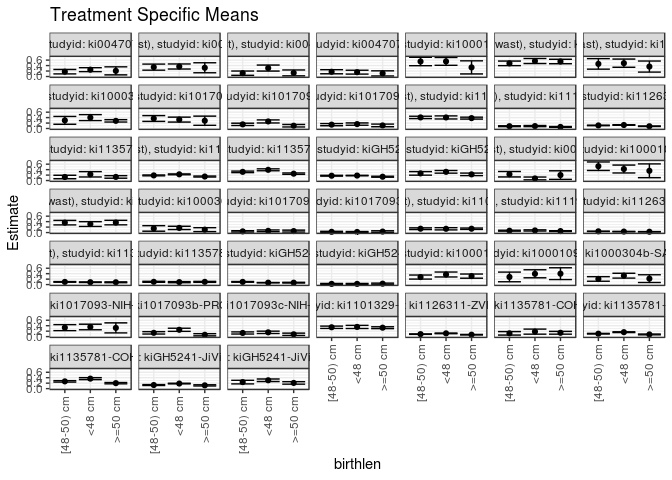

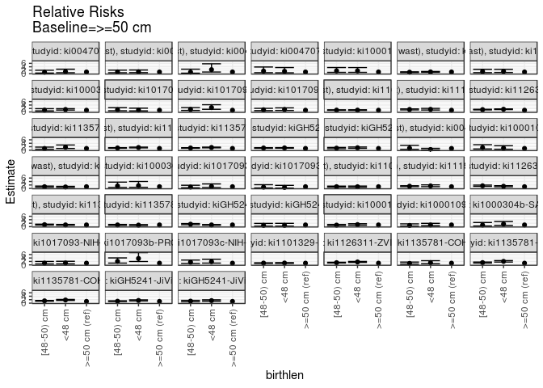

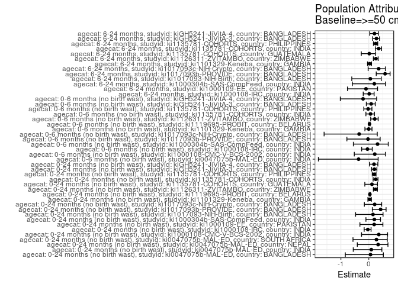

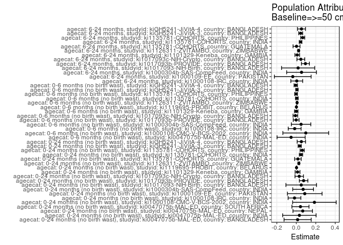

## Results Table

### Parameter: TSM

| agecat | studyid | country | intervention_level | baseline_level | estimate | ci_lower | ci_upper |
| --- | --- | --- | --- | --- | --- | --- | --- |
| 0-24 months (no birth wast) | ki0047075b-MAL-ED | BANGLADESH | >=50 cm | NA | 0.2068966 | 0.0591739 | 0.3546193 |
| 0-24 months (no birth wast) | ki0047075b-MAL-ED | BANGLADESH | <48 cm | NA | 0.2500000 | 0.1781310 | 0.3218690 |
| 0-24 months (no birth wast) | ki0047075b-MAL-ED | BANGLADESH | [48-50) cm | NA | 0.1764706 | 0.0952678 | 0.2576734 |
| 0-24 months (no birth wast) | ki0047075b-MAL-ED | INDIA | >=50 cm | NA | 0.3200000 | 0.1366835 | 0.5033165 |
| 0-24 months (no birth wast) | ki0047075b-MAL-ED | INDIA | <48 cm | NA | 0.3653846 | 0.2726043 | 0.4581649 |
| 0-24 months (no birth wast) | ki0047075b-MAL-ED | INDIA | [48-50) cm | NA | 0.3428571 | 0.2313816 | 0.4543327 |
| 0-24 months (no birth wast) | ki0047075b-MAL-ED | NEPAL | >=50 cm | NA | 0.1315789 | 0.0237884 | 0.2393695 |
| 0-24 months (no birth wast) | ki0047075b-MAL-ED | NEPAL | <48 cm | NA | 0.3088235 | 0.1986926 | 0.4189545 |
| 0-24 months (no birth wast) | ki0047075b-MAL-ED | NEPAL | [48-50) cm | NA | 0.1212121 | 0.0422430 | 0.2001812 |
| 0-24 months (no birth wast) | ki0047075b-MAL-ED | SOUTH AFRICA | >=50 cm | NA | 0.1136364 | 0.0196680 | 0.2076048 |
| 0-24 months (no birth wast) | ki0047075b-MAL-ED | SOUTH AFRICA | <48 cm | NA | 0.1584158 | 0.0870598 | 0.2297719 |
| 0-24 months (no birth wast) | ki0047075b-MAL-ED | SOUTH AFRICA | [48-50) cm | NA | 0.1734694 | 0.0983467 | 0.2485921 |
| 0-24 months (no birth wast) | ki1000108-CMC-V-BCS-2002 | INDIA | >=50 cm | NA | 0.3333333 | 0.0935960 | 0.5730706 |
| 0-24 months (no birth wast) | ki1000108-CMC-V-BCS-2002 | INDIA | <48 cm | NA | 0.5531915 | 0.4103557 | 0.6960273 |
| 0-24 months (no birth wast) | ki1000108-CMC-V-BCS-2002 | INDIA | [48-50) cm | NA | 0.5500000 | 0.3950666 | 0.7049334 |
| 0-24 months (no birth wast) | ki1000108-IRC | INDIA | >=50 cm | NA | 0.5492958 | 0.4673531 | 0.6312385 |
| 0-24 months (no birth wast) | ki1000108-IRC | INDIA | <48 cm | NA | 0.5675676 | 0.4752866 | 0.6598485 |
| 0-24 months (no birth wast) | ki1000108-IRC | INDIA | [48-50) cm | NA | 0.4817518 | 0.3979746 | 0.5655290 |
| 0-24 months (no birth wast) | ki1000109-EE | PAKISTAN | >=50 cm | NA | 0.3636364 | 0.1615102 | 0.5657625 |
| 0-24 months (no birth wast) | ki1000109-EE | PAKISTAN | <48 cm | NA | 0.4883721 | 0.3381389 | 0.6386053 |
| 0-24 months (no birth wast) | ki1000109-EE | PAKISTAN | [48-50) cm | NA | 0.4615385 | 0.2688560 | 0.6542209 |
| 0-24 months (no birth wast) | ki1000304b-SAS-CompFeed | INDIA | >=50 cm | NA | 0.2807018 | 0.2371405 | 0.3242630 |
| 0-24 months (no birth wast) | ki1000304b-SAS-CompFeed | INDIA | <48 cm | NA | 0.4000000 | 0.2907856 | 0.5092144 |
| 0-24 months (no birth wast) | ki1000304b-SAS-CompFeed | INDIA | [48-50) cm | NA | 0.2987013 | 0.1552242 | 0.4421784 |
| 0-24 months (no birth wast) | ki1017093-NIH-Birth | BANGLADESH | >=50 cm | NA | 0.2857143 | 0.1179874 | 0.4534411 |
| 0-24 months (no birth wast) | ki1017093-NIH-Birth | BANGLADESH | <48 cm | NA | 0.3269231 | 0.2365544 | 0.4172918 |
| 0-24 months (no birth wast) | ki1017093-NIH-Birth | BANGLADESH | [48-50) cm | NA | 0.3670886 | 0.2605461 | 0.4736311 |
| 0-24 months (no birth wast) | ki1017093b-PROVIDE | BANGLADESH | >=50 cm | NA | 0.1024096 | 0.0562545 | 0.1485648 |
| 0-24 months (no birth wast) | ki1017093b-PROVIDE | BANGLADESH | <48 cm | NA | 0.2594142 | 0.2038046 | 0.3150239 |
| 0-24 months (no birth wast) | ki1017093b-PROVIDE | BANGLADESH | [48-50) cm | NA | 0.1524823 | 0.1104944 | 0.1944701 |

[output cut: 105 more lines]

### Parameter: E(Y)

| agecat | studyid | country | intervention_level | baseline_level | estimate | ci_lower | ci_upper |
| --- | --- | --- | --- | --- | --- | --- | --- |
| 0-24 months (no birth wast) | ki0047075b-MAL-ED | BANGLADESH | NA | NA | 0.2204724 | 0.1693889 | 0.2715560 |
| 0-24 months (no birth wast) | ki0047075b-MAL-ED | INDIA | NA | NA | 0.3517588 | 0.2852458 | 0.4182718 |
| 0-24 months (no birth wast) | ki0047075b-MAL-ED | NEPAL | NA | NA | 0.1976744 | 0.1379846 | 0.2573643 |
| 0-24 months (no birth wast) | ki0047075b-MAL-ED | SOUTH AFRICA | NA | NA | 0.1563786 | 0.1106168 | 0.2021404 |
| 0-24 months (no birth wast) | ki1000108-CMC-V-BCS-2002 | INDIA | NA | NA | 0.5196078 | 0.4221710 | 0.6170447 |
| 0-24 months (no birth wast) | ki1000108-IRC | INDIA | NA | NA | 0.5307692 | 0.4811763 | 0.5803621 |
| 0-24 months (no birth wast) | ki1000109-EE | PAKISTAN | NA | NA | 0.4505495 | 0.3477567 | 0.5533422 |
| 0-24 months (no birth wast) | ki1000304b-SAS-CompFeed | INDIA | NA | NA | 0.3508772 | 0.2566771 | 0.4450772 |
| 0-24 months (no birth wast) | ki1017093-NIH-Birth | BANGLADESH | NA | NA | 0.3364929 | 0.2725858 | 0.4004000 |
| 0-24 months (no birth wast) | ki1017093b-PROVIDE | BANGLADESH | NA | NA | 0.1775837 | 0.1489858 | 0.2061816 |
| 0-24 months (no birth wast) | ki1017093c-NIH-Crypto | BANGLADESH | NA | NA | 0.1432361 | 0.1182149 | 0.1682572 |
| 0-24 months (no birth wast) | ki1101329-Keneba | GAMBIA | NA | NA | 0.3939198 | 0.3695556 | 0.4182840 |
| 0-24 months (no birth wast) | ki1119695-PROBIT | BELARUS | NA | NA | 0.0612597 | 0.0474556 | 0.0750638 |
| 0-24 months (no birth wast) | ki1126311-ZVITAMBO | ZIMBABWE | NA | NA | 0.1091366 | 0.1036313 | 0.1146419 |
| 0-24 months (no birth wast) | ki1135781-COHORTS | GUATEMALA | NA | NA | 0.1492147 | 0.1134379 | 0.1849914 |
| 0-24 months (no birth wast) | ki1135781-COHORTS | INDIA | NA | NA | 0.1954545 | 0.1857233 | 0.2051858 |
| 0-24 months (no birth wast) | ki1135781-COHORTS | PHILIPPINES | NA | NA | 0.3118390 | 0.2950654 | 0.3286125 |
| 0-24 months (no birth wast) | kiGH5241-JiVitA-3 | BANGLADESH | NA | NA | 0.1748553 | 0.1668952 | 0.1828153 |
| 0-24 months (no birth wast) | kiGH5241-JiVitA-4 | BANGLADESH | NA | NA | 0.2783945 | 0.2477970 | 0.3089921 |
| 0-6 months (no birth wast) | ki0047075b-MAL-ED | INDIA | NA | NA | 0.1464646 | 0.0970913 | 0.1958379 |
| 0-6 months (no birth wast) | ki1000108-CMC-V-BCS-2002 | INDIA | NA | NA | 0.4545455 | 0.3559622 | 0.5531287 |
| 0-6 months (no birth wast) | ki1000108-IRC | INDIA | NA | NA | 0.3494624 | 0.3009450 | 0.3979798 |
| 0-6 months (no birth wast) | ki1000304b-SAS-CompFeed | INDIA | NA | NA | 0.1562500 | 0.0949206 | 0.2175794 |
| 0-6 months (no birth wast) | ki1017093b-PROVIDE | BANGLADESH | NA | NA | 0.0527086 | 0.0359384 | 0.0694789 |
| 0-6 months (no birth wast) | ki1017093c-NIH-Crypto | BANGLADESH | NA | NA | 0.0267023 | 0.0151493 | 0.0382553 |
| 0-6 months (no birth wast) | ki1101329-Keneba | GAMBIA | NA | NA | 0.1404087 | 0.1229206 | 0.1578968 |
| 0-6 months (no birth wast) | ki1119695-PROBIT | BELARUS | NA | NA | 0.0550194 | 0.0412334 | 0.0688054 |
| 0-6 months (no birth wast) | ki1126311-ZVITAMBO | ZIMBABWE | NA | NA | 0.0376159 | 0.0341115 | 0.0411202 |
| 0-6 months (no birth wast) | ki1135781-COHORTS | INDIA | NA | NA | 0.0905846 | 0.0832504 | 0.0979189 |
| 0-6 months (no birth wast) | ki1135781-COHORTS | PHILIPPINES | NA | NA | 0.0980256 | 0.0871772 | 0.1088741 |
| 0-6 months (no birth wast) | kiGH5241-JiVitA-3 | BANGLADESH | NA | NA | 0.0759915 | 0.0706126 | 0.0813703 |
| 0-6 months (no birth wast) | kiGH5241-JiVitA-4 | BANGLADESH | NA | NA | 0.0275801 | 0.0176087 | 0.0375515 |
| 6-24 months | ki1000108-IRC | INDIA | NA | NA | 0.3145780 | 0.2684931 | 0.3606629 |
| 6-24 months | ki1000109-EE | PAKISTAN | NA | NA | 0.3636364 | 0.2625541 | 0.4647186 |
| 6-24 months | ki1000304b-SAS-CompFeed | INDIA | NA | NA | 0.2720930 | 0.2192075 | 0.3249786 |
| 6-24 months | ki1017093-NIH-Birth | BANGLADESH | NA | NA | 0.3388889 | 0.2695483 | 0.4082295 |
| 6-24 months | ki1017093b-PROVIDE | BANGLADESH | NA | NA | 0.1609756 | 0.1319065 | 0.1900447 |
| 6-24 months | ki1017093c-NIH-Crypto | BANGLADESH | NA | NA | 0.1315068 | 0.1069744 | 0.1560393 |
| 6-24 months | ki1101329-Keneba | GAMBIA | NA | NA | 0.3369200 | 0.3128882 | 0.3609517 |
| 6-24 months | ki1126311-ZVITAMBO | ZIMBABWE | NA | NA | 0.0937559 | 0.0881988 | 0.0993131 |
| 6-24 months | ki1135781-COHORTS | GUATEMALA | NA | NA | 0.1420290 | 0.1051403 | 0.1789177 |
| 6-24 months | ki1135781-COHORTS | INDIA | NA | NA | 0.1238450 | 0.1156244 | 0.1320657 |
| 6-24 months | ki1135781-COHORTS | PHILIPPINES | NA | NA | 0.2665953 | 0.2502200 | 0.2829706 |
| 6-24 months | kiGH5241-JiVitA-3 | BANGLADESH | NA | NA | 0.1651770 | 0.1558486 | 0.1745053 |
| 6-24 months | kiGH5241-JiVitA-4 | BANGLADESH | NA | NA | 0.2623090 | 0.2322804 | 0.2923376 |

### Parameter: RR

| agecat | studyid | country | intervention_level | baseline_level | estimate | ci_lower | ci_upper |
| --- | --- | --- | --- | --- | --- | --- | --- |
| 0-24 months (no birth wast) | ki0047075b-MAL-ED | BANGLADESH | >=50 cm | >=50 cm | 1.0000000 | 1.0000000 | 1.000000 |
| 0-24 months (no birth wast) | ki0047075b-MAL-ED | BANGLADESH | <48 cm | >=50 cm | 1.2083333 | 0.5596455 | 2.608918 |
| 0-24 months (no birth wast) | ki0047075b-MAL-ED | BANGLADESH | [48-50) cm | >=50 cm | 0.8529412 | 0.3647694 | 1.994435 |
| 0-24 months (no birth wast) | ki0047075b-MAL-ED | INDIA | >=50 cm | >=50 cm | 1.0000000 | 1.0000000 | 1.000000 |
| 0-24 months (no birth wast) | ki0047075b-MAL-ED | INDIA | <48 cm | >=50 cm | 1.1418269 | 0.6101874 | 2.136669 |
| 0-24 months (no birth wast) | ki0047075b-MAL-ED | INDIA | [48-50) cm | >=50 cm | 1.0714286 | 0.5544890 | 2.070301 |
| 0-24 months (no birth wast) | ki0047075b-MAL-ED | NEPAL | >=50 cm | >=50 cm | 1.0000000 | 1.0000000 | 1.000000 |
| 0-24 months (no birth wast) | ki0047075b-MAL-ED | NEPAL | <48 cm | >=50 cm | 2.3470588 | 0.9605011 | 5.735220 |
| 0-24 months (no birth wast) | ki0047075b-MAL-ED | NEPAL | [48-50) cm | >=50 cm | 0.9212121 | 0.3234374 | 2.623789 |
| 0-24 months (no birth wast) | ki0047075b-MAL-ED | SOUTH AFRICA | >=50 cm | >=50 cm | 1.0000000 | 1.0000000 | 1.000000 |
| 0-24 months (no birth wast) | ki0047075b-MAL-ED | SOUTH AFRICA | <48 cm | >=50 cm | 1.3940594 | 0.5436644 | 3.574635 |
| 0-24 months (no birth wast) | ki0047075b-MAL-ED | SOUTH AFRICA | [48-50) cm | >=50 cm | 1.5265306 | 0.6002200 | 3.882403 |
| 0-24 months (no birth wast) | ki1000108-CMC-V-BCS-2002 | INDIA | >=50 cm | >=50 cm | 1.0000000 | 1.0000000 | 1.000000 |
| 0-24 months (no birth wast) | ki1000108-CMC-V-BCS-2002 | INDIA | <48 cm | >=50 cm | 1.6595745 | 0.7729083 | 3.563408 |
| 0-24 months (no birth wast) | ki1000108-CMC-V-BCS-2002 | INDIA | [48-50) cm | >=50 cm | 1.6500000 | 0.7621317 | 3.572217 |
| 0-24 months (no birth wast) | ki1000108-IRC | INDIA | >=50 cm | >=50 cm | 1.0000000 | 1.0000000 | 1.000000 |
| 0-24 months (no birth wast) | ki1000108-IRC | INDIA | <48 cm | >=50 cm | 1.0332640 | 0.8286690 | 1.288373 |
| 0-24 months (no birth wast) | ki1000108-IRC | INDIA | [48-50) cm | >=50 cm | 0.8770354 | 0.6974481 | 1.102865 |
| 0-24 months (no birth wast) | ki1000109-EE | PAKISTAN | >=50 cm | >=50 cm | 1.0000000 | 1.0000000 | 1.000000 |
| 0-24 months (no birth wast) | ki1000109-EE | PAKISTAN | <48 cm | >=50 cm | 1.3430233 | 0.7115078 | 2.535055 |
| 0-24 months (no birth wast) | ki1000109-EE | PAKISTAN | [48-50) cm | >=50 cm | 1.2692308 | 0.6333362 | 2.543589 |
| 0-24 months (no birth wast) | ki1000304b-SAS-CompFeed | INDIA | >=50 cm | >=50 cm | 1.0000000 | 1.0000000 | 1.000000 |
| 0-24 months (no birth wast) | ki1000304b-SAS-CompFeed | INDIA | <48 cm | >=50 cm | 1.4250000 | 1.0783744 | 1.883043 |
| 0-24 months (no birth wast) | ki1000304b-SAS-CompFeed | INDIA | [48-50) cm | >=50 cm | 1.0641234 | 0.6025741 | 1.879202 |
| 0-24 months (no birth wast) | ki1017093-NIH-Birth | BANGLADESH | >=50 cm | >=50 cm | 1.0000000 | 1.0000000 | 1.000000 |
| 0-24 months (no birth wast) | ki1017093-NIH-Birth | BANGLADESH | <48 cm | >=50 cm | 1.1442308 | 0.5980174 | 2.189341 |
| 0-24 months (no birth wast) | ki1017093-NIH-Birth | BANGLADESH | [48-50) cm | >=50 cm | 1.2848101 | 0.6674695 | 2.473127 |
| 0-24 months (no birth wast) | ki1017093b-PROVIDE | BANGLADESH | >=50 cm | >=50 cm | 1.0000000 | 1.0000000 | 1.000000 |
| 0-24 months (no birth wast) | ki1017093b-PROVIDE | BANGLADESH | <48 cm | >=50 cm | 2.5331036 | 1.5378276 | 4.172518 |
| 0-24 months (no birth wast) | ki1017093b-PROVIDE | BANGLADESH | [48-50) cm | >=50 cm | 1.4889445 | 0.8780192 | 2.524951 |

[output cut: 105 more lines]

### Parameter: PAR

| agecat | studyid | country | intervention_level | baseline_level | estimate | ci_lower | ci_upper |
| --- | --- | --- | --- | --- | --- | --- | --- |
| 0-24 months (no birth wast) | ki0047075b-MAL-ED | BANGLADESH | >=50 cm | NA | 0.0135759 | -0.1258822 | 0.1530339 |
| 0-24 months (no birth wast) | ki0047075b-MAL-ED | INDIA | >=50 cm | NA | 0.0317588 | -0.1402454 | 0.2037630 |
| 0-24 months (no birth wast) | ki0047075b-MAL-ED | NEPAL | >=50 cm | NA | 0.0660955 | -0.0341432 | 0.1663342 |
| 0-24 months (no birth wast) | ki0047075b-MAL-ED | SOUTH AFRICA | >=50 cm | NA | 0.0427422 | -0.0451582 | 0.1306427 |
| 0-24 months (no birth wast) | ki1000108-CMC-V-BCS-2002 | INDIA | >=50 cm | NA | 0.1862745 | -0.0374749 | 0.4100239 |
| 0-24 months (no birth wast) | ki1000108-IRC | INDIA | >=50 cm | NA | -0.0185265 | -0.0839823 | 0.0469292 |
| 0-24 months (no birth wast) | ki1000109-EE | PAKISTAN | >=50 cm | NA | 0.0869131 | -0.0910399 | 0.2648661 |
| 0-24 months (no birth wast) | ki1000304b-SAS-CompFeed | INDIA | >=50 cm | NA | 0.0701754 | -0.0367104 | 0.1770613 |
| 0-24 months (no birth wast) | ki1017093-NIH-Birth | BANGLADESH | >=50 cm | NA | 0.0507786 | -0.1065428 | 0.2081000 |
| 0-24 months (no birth wast) | ki1017093b-PROVIDE | BANGLADESH | >=50 cm | NA | 0.0751741 | 0.0313717 | 0.1189764 |
| 0-24 months (no birth wast) | ki1017093c-NIH-Crypto | BANGLADESH | >=50 cm | NA | 0.0301408 | -0.0134394 | 0.0737211 |
| 0-24 months (no birth wast) | ki1101329-Keneba | GAMBIA | >=50 cm | NA | 0.0128423 | -0.0118986 | 0.0375831 |
| 0-24 months (no birth wast) | ki1119695-PROBIT | BELARUS | >=50 cm | NA | 0.0023645 | 0.0010137 | 0.0037153 |
| 0-24 months (no birth wast) | ki1126311-ZVITAMBO | ZIMBABWE | >=50 cm | NA | 0.0261950 | 0.0182153 | 0.0341747 |
| 0-24 months (no birth wast) | ki1135781-COHORTS | GUATEMALA | >=50 cm | NA | 0.0168617 | -0.0167896 | 0.0505130 |
| 0-24 months (no birth wast) | ki1135781-COHORTS | INDIA | >=50 cm | NA | 0.0482684 | 0.0311958 | 0.0653409 |
| 0-24 months (no birth wast) | ki1135781-COHORTS | PHILIPPINES | >=50 cm | NA | 0.0606890 | 0.0394035 | 0.0819745 |
| 0-24 months (no birth wast) | kiGH5241-JiVitA-3 | BANGLADESH | >=50 cm | NA | 0.0352058 | 0.0187116 | 0.0517000 |
| 0-24 months (no birth wast) | kiGH5241-JiVitA-4 | BANGLADESH | >=50 cm | NA | 0.0522041 | 0.0095406 | 0.0948675 |
| 0-6 months (no birth wast) | ki0047075b-MAL-ED | INDIA | >=50 cm | NA | -0.0535354 | -0.1981311 | 0.0910604 |
| 0-6 months (no birth wast) | ki1000108-CMC-V-BCS-2002 | INDIA | >=50 cm | NA | 0.0974026 | -0.1378841 | 0.3326893 |
| 0-6 months (no birth wast) | ki1000108-IRC | INDIA | >=50 cm | NA | -0.0169498 | -0.0830740 | 0.0491743 |
| 0-6 months (no birth wast) | ki1000304b-SAS-CompFeed | INDIA | >=50 cm | NA | 0.0491071 | -0.0509653 | 0.1491796 |
| 0-6 months (no birth wast) | ki1017093b-PROVIDE | BANGLADESH | >=50 cm | NA | -0.0015082 | -0.0313738 | 0.0283573 |
| 0-6 months (no birth wast) | ki1017093c-NIH-Crypto | BANGLADESH | >=50 cm | NA | -0.0092259 | -0.0332159 | 0.0147641 |
| 0-6 months (no birth wast) | ki1101329-Keneba | GAMBIA | >=50 cm | NA | -0.0005309 | -0.0183340 | 0.0172722 |
| 0-6 months (no birth wast) | ki1119695-PROBIT | BELARUS | >=50 cm | NA | 0.0013938 | 0.0001449 | 0.0026427 |
| 0-6 months (no birth wast) | ki1126311-ZVITAMBO | ZIMBABWE | >=50 cm | NA | 0.0080283 | 0.0029522 | 0.0131044 |
| 0-6 months (no birth wast) | ki1135781-COHORTS | INDIA | >=50 cm | NA | 0.0055966 | -0.0081712 | 0.0193643 |
| 0-6 months (no birth wast) | ki1135781-COHORTS | PHILIPPINES | >=50 cm | NA | -0.0022555 | -0.0164837 | 0.0119727 |
| 0-6 months (no birth wast) | kiGH5241-JiVitA-3 | BANGLADESH | >=50 cm | NA | 0.0065084 | -0.0056026 | 0.0186194 |
| 0-6 months (no birth wast) | kiGH5241-JiVitA-4 | BANGLADESH | >=50 cm | NA | -0.0056526 | -0.0228546 | 0.0115495 |
| 6-24 months | ki1000108-IRC | INDIA | >=50 cm | NA | 0.0047189 | -0.0561992 | 0.0656369 |
| 6-24 months | ki1000109-EE | PAKISTAN | >=50 cm | NA | -0.0363636 | -0.2251776 | 0.1524504 |
| 6-24 months | ki1000304b-SAS-CompFeed | INDIA | >=50 cm | NA | 0.0539112 | -0.0991452 | 0.2069676 |
| 6-24 months | ki1017093-NIH-Birth | BANGLADESH | >=50 cm | NA | 0.0188889 | -0.1516728 | 0.1894506 |
| 6-24 months | ki1017093b-PROVIDE | BANGLADESH | >=50 cm | NA | 0.0938615 | 0.0528933 | 0.1348297 |
| 6-24 months | ki1017093c-NIH-Crypto | BANGLADESH | >=50 cm | NA | 0.0466584 | 0.0067363 | 0.0865805 |
| 6-24 months | ki1101329-Keneba | GAMBIA | >=50 cm | NA | 0.0098675 | -0.0141802 | 0.0339151 |
| 6-24 months | ki1126311-ZVITAMBO | ZIMBABWE | >=50 cm | NA | 0.0239042 | 0.0157865 | 0.0320218 |
| 6-24 months | ki1135781-COHORTS | GUATEMALA | >=50 cm | NA | 0.0023642 | -0.0331791 | 0.0379075 |
| 6-24 months | ki1135781-COHORTS | INDIA | >=50 cm | NA | 0.0441133 | 0.0304659 | 0.0577607 |
| 6-24 months | ki1135781-COHORTS | PHILIPPINES | >=50 cm | NA | 0.0660167 | 0.0454611 | 0.0865723 |
| 6-24 months | kiGH5241-JiVitA-3 | BANGLADESH | >=50 cm | NA | 0.0450769 | 0.0249809 | 0.0651729 |
| 6-24 months | kiGH5241-JiVitA-4 | BANGLADESH | >=50 cm | NA | 0.0533538 | 0.0121999 | 0.0945076 |

### Parameter: PAF

| agecat | studyid | country | intervention_level | baseline_level | estimate | ci_lower | ci_upper |
| --- | --- | --- | --- | --- | --- | --- | --- |
| 0-24 months (no birth wast) | ki0047075b-MAL-ED | BANGLADESH | >=50 cm | NA | 0.0615764 | -0.8411916 | 0.5217016 |
| 0-24 months (no birth wast) | ki0047075b-MAL-ED | INDIA | >=50 cm | NA | 0.0902857 | -0.5571922 | 0.4685434 |
| 0-24 months (no birth wast) | ki0047075b-MAL-ED | NEPAL | >=50 cm | NA | 0.3343653 | -0.4114022 | 0.6860785 |
| 0-24 months (no birth wast) | ki0047075b-MAL-ED | SOUTH AFRICA | >=50 cm | NA | 0.2733254 | -0.5659685 | 0.6627927 |
| 0-24 months (no birth wast) | ki1000108-CMC-V-BCS-2002 | INDIA | >=50 cm | NA | 0.3584906 | -0.2592056 | 0.6731794 |
| 0-24 months (no birth wast) | ki1000108-IRC | INDIA | >=50 cm | NA | -0.0349051 | -0.1659411 | 0.0814043 |
| 0-24 months (no birth wast) | ki1000109-EE | PAKISTAN | >=50 cm | NA | 0.1929047 | -0.3179000 | 0.5057266 |
| 0-24 months (no birth wast) | ki1000304b-SAS-CompFeed | INDIA | >=50 cm | NA | 0.2000000 | -0.1023779 | 0.4194369 |
| 0-24 months (no birth wast) | ki1017093-NIH-Birth | BANGLADESH | >=50 cm | NA | 0.1509054 | -0.4724043 | 0.5103508 |
| 0-24 months (no birth wast) | ki1017093b-PROVIDE | BANGLADESH | >=50 cm | NA | 0.4233162 | 0.1264523 | 0.6192948 |
| 0-24 months (no birth wast) | ki1017093c-NIH-Crypto | BANGLADESH | >=50 cm | NA | 0.2104277 | -0.1583561 | 0.4618024 |
| 0-24 months (no birth wast) | ki1101329-Keneba | GAMBIA | >=50 cm | NA | 0.0326012 | -0.0322982 | 0.0934205 |
| 0-24 months (no birth wast) | ki1119695-PROBIT | BELARUS | >=50 cm | NA | 0.0385980 | 0.0140688 | 0.0625169 |
| 0-24 months (no birth wast) | ki1126311-ZVITAMBO | ZIMBABWE | >=50 cm | NA | 0.2400200 | 0.1641735 | 0.3089839 |
| 0-24 months (no birth wast) | ki1135781-COHORTS | GUATEMALA | >=50 cm | NA | 0.1130031 | -0.1423339 | 0.3112666 |
| 0-24 months (no birth wast) | ki1135781-COHORTS | INDIA | >=50 cm | NA | 0.2469546 | 0.1549571 | 0.3289366 |
| 0-24 months (no birth wast) | ki1135781-COHORTS | PHILIPPINES | >=50 cm | NA | 0.1946165 | 0.1236189 | 0.2598624 |
| 0-24 months (no birth wast) | kiGH5241-JiVitA-3 | BANGLADESH | >=50 cm | NA | 0.2013423 | 0.1011812 | 0.2903417 |
| 0-24 months (no birth wast) | kiGH5241-JiVitA-4 | BANGLADESH | >=50 cm | NA | 0.1875183 | 0.0226016 | 0.3246085 |
| 0-6 months (no birth wast) | ki0047075b-MAL-ED | INDIA | >=50 cm | NA | -0.3655172 | -1.8053088 | 0.3353183 |
| 0-6 months (no birth wast) | ki1000108-CMC-V-BCS-2002 | INDIA | >=50 cm | NA | 0.2142857 | -0.5196227 | 0.5937499 |
| 0-6 months (no birth wast) | ki1000108-IRC | INDIA | >=50 cm | NA | -0.0485026 | -0.2558860 | 0.1246357 |
| 0-6 months (no birth wast) | ki1000304b-SAS-CompFeed | INDIA | >=50 cm | NA | 0.3142857 | -0.5528914 | 0.6972074 |
| 0-6 months (no birth wast) | ki1017093b-PROVIDE | BANGLADESH | >=50 cm | NA | -0.0286144 | -0.7842598 | 0.4070103 |
| 0-6 months (no birth wast) | ki1017093c-NIH-Crypto | BANGLADESH | >=50 cm | NA | -0.3455090 | -1.6009534 | 0.3039497 |
| 0-6 months (no birth wast) | ki1101329-Keneba | GAMBIA | >=50 cm | NA | -0.0037811 | -0.1389317 | 0.1153320 |
| 0-6 months (no birth wast) | ki1119695-PROBIT | BELARUS | >=50 cm | NA | 0.0253336 | 0.0019922 | 0.0481291 |
| 0-6 months (no birth wast) | ki1126311-ZVITAMBO | ZIMBABWE | >=50 cm | NA | 0.2134291 | 0.0678548 | 0.3362689 |
| 0-6 months (no birth wast) | ki1135781-COHORTS | INDIA | >=50 cm | NA | 0.0617826 | -0.1031298 | 0.2020414 |
| 0-6 months (no birth wast) | ki1135781-COHORTS | PHILIPPINES | >=50 cm | NA | -0.0230096 | -0.1789391 | 0.1122963 |
| 0-6 months (no birth wast) | kiGH5241-JiVitA-3 | BANGLADESH | >=50 cm | NA | 0.0856465 | -0.0882067 | 0.2317248 |
| 0-6 months (no birth wast) | kiGH5241-JiVitA-4 | BANGLADESH | >=50 cm | NA | -0.2049508 | -1.0208128 | 0.2815236 |
| 6-24 months | ki1000108-IRC | INDIA | >=50 cm | NA | 0.0150006 | -0.1989951 | 0.1908025 |
| 6-24 months | ki1000109-EE | PAKISTAN | >=50 cm | NA | -0.1000000 | -0.7638855 | 0.3140144 |
| 6-24 months | ki1000304b-SAS-CompFeed | INDIA | >=50 cm | NA | 0.1981352 | -0.5894576 | 0.5954676 |
| 6-24 months | ki1017093-NIH-Birth | BANGLADESH | >=50 cm | NA | 0.0557377 | -0.6090591 | 0.4458679 |
| 6-24 months | ki1017093b-PROVIDE | BANGLADESH | >=50 cm | NA | 0.5830791 | 0.2665679 | 0.7630005 |
| 6-24 months | ki1017093c-NIH-Crypto | BANGLADESH | >=50 cm | NA | 0.3547980 | -0.0235052 | 0.5932745 |
| 6-24 months | ki1101329-Keneba | GAMBIA | >=50 cm | NA | 0.0292873 | -0.0447768 | 0.0981010 |
| 6-24 months | ki1126311-ZVITAMBO | ZIMBABWE | >=50 cm | NA | 0.2549619 | 0.1644075 | 0.3357027 |
| 6-24 months | ki1135781-COHORTS | GUATEMALA | >=50 cm | NA | 0.0166458 | -0.2683017 | 0.2375745 |
| 6-24 months | ki1135781-COHORTS | INDIA | >=50 cm | NA | 0.3561975 | 0.2384891 | 0.4557114 |
| 6-24 months | ki1135781-COHORTS | PHILIPPINES | >=50 cm | NA | 0.2476289 | 0.1671914 | 0.3202973 |
| 6-24 months | kiGH5241-JiVitA-3 | BANGLADESH | >=50 cm | NA | 0.2729006 | 0.1396086 | 0.3855429 |
| 6-24 months | kiGH5241-JiVitA-4 | BANGLADESH | >=50 cm | NA | 0.2034005 | 0.0348900 | 0.3424886 |